# R Notebook

```r
library(prob)
```

# Question 1

## Load, clean and explore data

```r
customer_data <- read_csv("data/20190928-items.csv") %>%
  clean_names()
```

# Question 2

## Find the brand with the highest numbers of phones in the dataset.

| brand | count |
| --- | --- |
| Samsung | 397 |
| Apple | 101 |
| Motorola | 100 |
| Nokia | 49 |
| HUAWEI | 36 |
| Google | 33 |
| Sony | 29 |
| Xiaomi | 27 |
| ASUS | 13 |
| OnePlus | 7 |

*Solution*

Samsung is most popular brand of phone with 397 reviews left from one.

# Question 3

## For your top brand, plot the distribution of phone ratings as a probability density, overlaying a fitted normal distribution. Do you think the normal distribution provides a good model of these ratings?

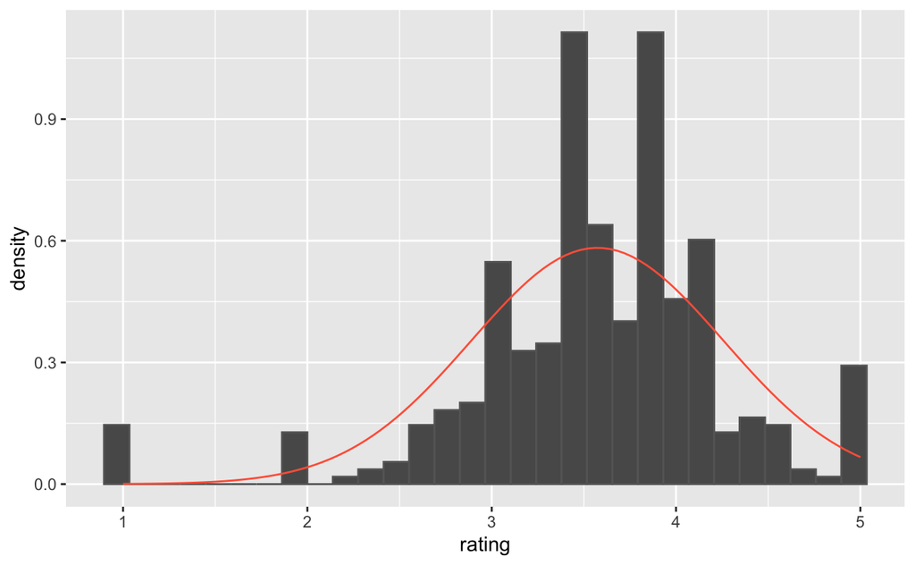

```r
samsung_stats <- customer_data %>%
  dplyr::filter(brand == "Samsung") %>%
  summarise(
    num = n(),
    mean = mean(rating),
    sd = sd(rating)
  )

customer_data %>%
  dplyr::filter(brand == "Samsung") %>%
  ggplot(aes(x = rating)) +
  geom_histogram(aes(y = ..density..), col = "grey40", bins = 30) +
  stat_function(
    fun = dnorm,
    args = list(
      mean = samsung_stats$mean,
      sd = samsung_stats$sd
    ),
    col = "tomato"
  )
```

*Solution*

The normal distribution provides an approximate model of our data, though it is not perfect, it provides a ‘loose’ fit. Our data generally follows a bell curve, with a few extra peaks.

# Question 4

## We can be more quantitative in comparing the distribution of top brand ratings with a normal distribution. You calculated the mean() and sd() of your distribution in an earlier question. Use these values to calculate the proportions of ratings within one-, two- and three standard deviations of the mean. Compare these proportions with those you expect for a normal distribution.

**within 1 sd ~ 68% expected**

```r
(count / nrow(samsung_scaled))*100
```

```
[1] 79.34509
```

*Solution*

79.3% of our data is within 1 sd of the sample mean. This is greater than the 68% we would expect if it followed a normal distribution.

**within 2 sd ~ 95% expected**

```r
count <- samsung_scaled %>%
  dplyr::filter(between(z_rating, left = -2, right = 2)) %>%
  nrow()

(count / nrow(samsung_scaled))*100
```

```
[1] 91.93955
```

*Solution*

91.9% of our data lies within 2 sd of our sample mean, which falls narrowly short of our benchmark of 95% we would expect if it followed a normal distribution.

**within 3 sd ~ 99.7% expected**

```r
count <- samsung_scaled %>%
  dplyr::filter(between(z_rating, left = -3, right = 3)) %>%
  nrow()

(count / nrow(samsung_scaled))*100
```

```
[1] 97.98489
```

*Solution*

98.0% of our data lies within 3 sd, again, narrowly falling short of the 99.7% we would expect to lie within 3 sd if it were to follow a normal distribution.

**Overall comments on the distribution**

After overlaying a fitted normal distribution onto our earlier probability density plot, it was apparent that our data ‘loosely’ followed a normal distribution, but not with 100% confidence (much like all statistics). The above calculations prove this point empirically, with us only managing to satisy the 68% portion of the empirical rule and falling slightly short on the 95% & 99.7%.